# Análisis de oportunidades e ideas de pequeño negocio o microempresa

## Creación y Gestión de Microempresas

## Índice

## Contenidos

### Identificación de oportunidades e ideas de negocio.

- Necesidades y tendencias.
- Fuentes de búsqueda.
- La curiosidad como fuente de valor y búsqueda de oportunidades.
- Técnicas de creatividad en la generación de ideas.
- Los mapas mentales.
- Técnica de Edward de Bono (Seis sombreros).
- El pensamiento irradiante.

## Contenidos

### Análisis DAFO de la oportunidad e idea negocio.

- Utilidad y limitaciones.
- Estructura: Debilidades, Amenazas, Fortalezas, Oportunidades.
- Elaboración del DAFO.
- Interpretación del DAFO.

## Contenidos

### Análisis del entorno del pequeño negocio o microempresa.

- Elección de las fuentes de información.
- La segmentación del mercado.
- La descentralización productiva como estrategia de racionalización.
- La externalización de servicios: «Outsourcing».
- Clientes potenciales.
- Canales de distribución.
- Proveedores.
- Competencia.
- Barreras de entrada.

## Contenidos

### Análisis de decisiones previas.

- Objetivos y metas.
- Misión del negocio.
- Los trámites administrativos: licencias, permisos, reglamentación y otros.
- Visión del negocio.

## Identificación de oportunidades e ideas de negocio

## Necesidades y tendencias

**Comportamiento de compra:** Todas las acciones y decisiones que un individuo pone en marcha desde que percibe una necesidad hasta que consigue satisfacerla por medio de la adquisición de un producto o servicio.

Las necesidades son la base que fundamenta el proceso de intercambio. Se hace necesario pues estudiarlas ya que la información recabada será esencial para el negocio. Estos conocimientos permitirán a la empresa:

- Diseñar una estrategia comercial a medida del cliente, es decir, que se adapte al consumidor de la forma más efectiva y duradera posible para ganar su confianza.
- Detectar oportunidades actuales y futuras en cuanto a que la empresa podrá predecir los movimientos de los clientes en el futuro.

## Necesidades

### Pirámide de Maslow

[figure not shown]

## Necesidades y tendencias.

**Necesidad:** Sensación de carencia que se percibe cuando se precisa algo con más o menos intensidad de forma tal que, moviliza la acción y voluntad de un sujeto hacia la consecución o alcance de un objeto, acción o actividad que satisface la carencia inicial que motivó la movilización.

### Categorías de las necesidades:

- **Existenciales:** de ser (atributos personales y colectivos), de tener (instituciones, normas, leyes), de hacer (acciones personales y colectivas) y de estar (espacios).
- **Axiológicas:** subsistencia, protección, afecto, entendimiento, participación, ocio, creación, identidad y libertad.

## Necesidades y tendencias.

### Atributos de una oportunidad de negocio

- Debe ser la respuesta a una necesidad
- Debe reflejar las características del producto requerido (bien o servicio)
- Debe sugerir el perfil de los clientes potenciales
- Debe permitir poner en práctica las capacidades, conocimientos e intereses de sus promotores.

## Necesidades y tendencias.

### Las tendencias

Debemos analizar con detenimiento las características de los cambios que ocurren en nuestra sociedad y que pueden describir en cierta forma algunas tendencias, permiten identificar áreas en las cuáles descifrar oportunidades de negocio.

## Necesidades y tendencias.

### Las tendencias

En la actualidad, anticiparse a los demás competidores y prever los hábitos de compra de los consumidores es esencial para diseñar estrategias comerciales, por eso, es importante extraer información de las tendencias de los sujetos involucrados en los intercambios.

## Necesidades y tendencias.

### Las tendencias

**Tendencia del consumidor:** Se refiere a las costumbres, hábitos e inclinaciones que se repiten y manifiestan en el acto de compra cuya observación permite a las empresas prever y determinar unas pautas de comportamiento uniforme.

## Necesidades y tendencias.

### Las tendencias

- Del entorno exterior al consumidor
  - Socioculturales
  - Económicos
  - Politicos
  - Tecnológicos
  - Demográficos
  - De marketing
- Del carácter interno
  - Personales
  - Grupos Sociales

## Necesidades y tendencias.

### Las tendencias

| Relacionadas con conductas y estilos de vida | Relacionadas con la situación económica nacional e internacional |
| --- | --- |
| **Estar en forma** artefactos, bebidas, etc. | **Caída del ingreso familiar** productos sustitutos con mejores precios |
| **Necesidad de información** smartphones, almacenamiento en la nube | **Interdependencia de las economías nacionales** oportunidades en torno a bienes y productos complementarios |
|  | **Aumento de las actividades en un sector de la economía nacional** seguimiento de las políticas gubernamentales, posibilidad de desarrollar actividades conexas. |

## Fuentes de búsqueda.

- Observación
- Análisis del comportamiento del consumidor, estudios de mercado
- Medios de comunicación/internet/redes sociales
- Experiencias propias en otros trabajos
- Bases de datos
- Cursos, talleres, seminarios
- Contactos personales
- Tendencias
- Modas
- Exposiciones, ferias, empresas de otros países

## La curiosidad como fuente de valor y búsqueda de oportunidades.

Los rasgos de empresarios o emprendedores que explotan la curiosidad como fuente para generar ideas y oportunidades son:

- Personas imaginativas y creativas.
- Personas abiertas a vivir nuevas experiencias.
- Desean firmemente adquirir conocimientos.
- Tienen especial sensibilidad para captar datos.
- Para ellos los detalles son muy importantes.
- Son personas optimistas y positivas.
- Escuchan la mayor parte del tiempo, no hablan demasiado excepto para preguntar.

## La curiosidad como fuente de valor y búsqueda de oportunidades.

- Lo cuestionan todo de una forma crítica y provechosa.
- Poseen empatía, piensan y se ponen verdaderamente en el lugar de otros.
- Aprenden de sus errores.
- Buscan una segunda o tercera opinión.
- Perseveran, indagan, llegan al fondo de los asuntos.
- Piensan diferente, usan el pensamiento divergente.

Las personas curiosas tienen inquietudes que les conducen de forma irremisible a buscar cosas nuevas nunca antes vistas u oídas. Además, lo hacen a partir de las más heterogéneas fuentes, las cuales observan hasta extraer conclusiones interesantes e incluso transformándolas de forma original y creativa.

## Técnicas de creatividad en la generación de ideas.

### Brainstorming

Es una técnica que se suele utilizar en grupo, pues cuantas más aportaciones mejor. En el proceso, destaca la presencia del moderador que induce al resto de los participantes a expresar sus ideas sin restricción o censura alguna a partir de un concepto clave o principal. El moderador suele ser un experto en la materia que conduce y controla el grupo hacia una meta relacionada con el objeto del problema.

Así, a partir del concepto o palabra clave, se van anotando las aportaciones de todos los participantes.

## Técnicas de creatividad en la generación de ideas.

### Brainstorming (fases)

1. **Determinación de objetivo y preparación:** ¿qué se busca? Una idea, un nuevo producto o una solución a un problema. Se determina el grupo participante: se recomienda que sea multidisciplinar y no menos de seis individuos. A este grupo hay que sumar la figura del moderador que no aporta ideas de arbitra el proceso y puede ser también el sujeto evaluador.
2. **Creatividad:** las ideas se liberan sin censura y son recopiladas a la vista de todos los participantes. En esta etapa lo importante es la cantidad.
3. **Evaluación:** se evalúa la calidad de ideas una a una, esto es tarea del evaluador que intentará conectar, combinar y perfeccionar alguna idea de la fase creativa con el objetivo.
4. **Clasificación:** se determina su posible aplicación a corto, medio o largo plazo.

## Técnicas de creatividad en la generación de ideas.

### La analogía

Consiste en la búsqueda de situaciones que se ajusten o planteen problemas similares al que se necesita resolver particularmente con el objetivo de estudiar sus soluciones satisfactorias e intentar aplicar o adaptar una de estas al caso que es objeto de análisis.

Además de potenciar la creatividad, las analogías, estimulan las capacidades de razonamiento, pues el cerebro se esfuerza por encontrar paralelismos y relaciones cuya originalidad y puntos comunes ofrecen nuevas perspectivas para resolver problemas o crear nuevas ideas.

## Técnicas de creatividad en la generación de ideas.

### Lista de atributos

Se divide el problema en sus elementos más importantes y nacen nuevas ideas a partir del análisis de sus atributos o características. Se puede realizar individualmente o en grupo.

Se recopilan todos los elementos y se analizan sus características en función de ciertos criterios o parámetros (u otras técnicas) sobre los que se desea que un producto mejore o en relación al propósito que se está buscando.

## El pensamiento irradiante

Se trata del pensamiento que se deriva, nace o se conecta a una idea central, palabra clave u origen. Se denomina irradiante porque se propaga en diversas direcciones de forma arbitraria a partir de un punto central como si fueran rayos luminosos que parten de un núcleo con luz.

Los estudios sobre la materia indican que el propio cerebro posee una estructura radial y establece mecanismos neuronales para enlazar pensamientos y crear asociaciones de ideas a partir de cosas, percepciones o estímulos centrales.

## Los mapas mentales

Los mapas mentales son métodos sencillos que pretende sacar el mayor partido al potente cerebro humano haciendo uso de esquemas, diagramas u organigramas usados para representar las ideas y pensamientos de una forma organizada.

Se basan en el pensamiento irradiante que es la forma en que el cerebro procesa la información. Los datos procedentes del cerebro se propagan en diferentes direcciones, es decir, de forma difusa o dispersa.

Ayudarán a pensar mejor, a distinguir las fortalezas y debilidades de las ideas, a discernir en situaciones de indecisión, a organizar ideas, a memorizar y extraer información.

## Los mapas mentales

[video not shown]

## Técnicas de creatividad en la generación de ideas.

### Seis sombreros

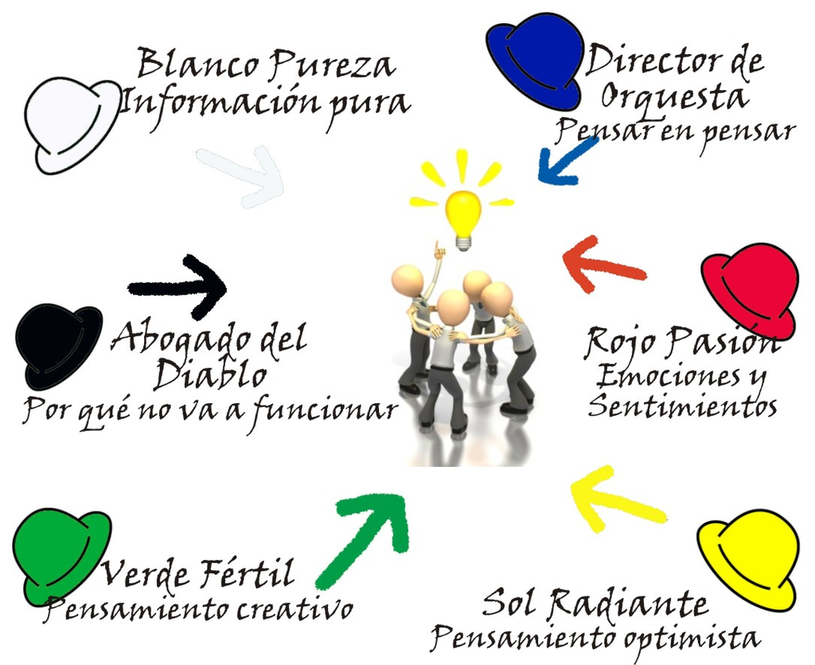

## Técnicas de creatividad en la generación de ideas.

### Seis sombreros

De Bono en su obra Seis Sombreros para pensar (1985) intenta aportar una guía o método sencillo para contribuir a un lenguaje constructivo orientado a que el ser humano aprenda a pensar mejor.

Al ponerse o quitarse el sombrero se indica una dirección de pensamiento determinado según su color.

Su funcionamiento se fundamenta principalmente en el pensamiento paralelo: un grupo piensa en conjunto para obtener el diseño de una idea o solución a un problema. Según de Bono, el método fomenta que todos los implicados piensen en una misma dirección y que los puntos de vista cosechados en el proceso de diseño, aunque sean contrarios, se sitúan al mismo nivel (en paralelo)

## Técnicas de creatividad en la generación de ideas.

### Seis sombreros

Si el diseño demanda que se eliminen puntos de vista enfrentados, se intenta llegar a un acuerdo sin afectar otras fases. Si no se llega a un acuerdo convincente, el diseño deberá contener o abarcar todos los puntos de vista incluso los enfrentados. El objetivo es no frenar el progreso hacia delante, el pensamiento en la misma dirección.

La confusión es la principal dificultad a la hora de pensar, pues en el proceso se aglutinan emociones, información, imaginación, ánimo, deseos o lógica. Con este método, se facilita la separación de estos factores dando a cada uno su lugar (su sombrero) y su momento de intervención.

## Técnicas de creatividad en la generación de ideas.

| Sombrero | Función |
| --- | --- |
| Blanco | Hechos y las cifras. Actitud de pensamiento neutro y objetivo, sin expresar emociones o puntos de vista, se actúa como una máquina. |
| Rojo | Sentimientos, emociones e intuiciones. Los participantes pueden expresar sus sentimientos sin justificación ni lógica alguna. |
| Negro | La cautela, señala los riesgos, errores o peligros que pueden tener las ideas o sugerencias. |
| Amarillo | Pensamiento constructivo, positivo, optimista. Investigan la lógica y el apoyo a las sugerencias aportadas. De él nacen las propuestas, las oportunidades, visiones, sueños y la efectividad. |
| Verde | La creatividad, las innovaciones, alternativas, percepciones y provocaciones para estimular el pensamiento lateral. |
| Azul | Control global del proceso. Dirige a los otros sombreros, modera, aclara, identifica y determina de una forma global. |

### Seis sombreros Edward de Bono

[video not shown]

## Análisis DAFO de la oportunidad e idea negocio

## Análisis DAFO de la oportunidad e idea negocio

Las siglas DAFO representan debilidades, amenazas, fortalezas, oportunidades. En Hispanoamérica se denomina normalmente FODA, y en países anglosajones SWOT.

Consiste en realizar un estudio completo interno (D/F) y externo (A/O) de la idea u oportunidad de negocio. Se trata de un ejercicio de clasificación de los diferentes aspectos de una idea para obtener los principales atributos y defectos de la misma.

## Análisis DAFO de la oportunidad e idea negocio

### Ventajas

- Permite contrastar los puntos fuertes y débiles de la idea, en relación a diferentes escenarios.
- Ayuda a evaluar objetivos e ideas
- Simplicidad
- Ayuda a diseñar estrategias y tácticas
- Permite establecer prioridades

### Inconvenientes:

- Las conclusiones pueden ser demasiado simples.
- Tiene carácter estático.
- Los resultados de un DAFO no son comparables con los de otro.

## DAFO

[figure not shown]

## DAFO

[figure not shown]

## DAFO

[figure not shown]

## Análisis DAFO de la oportunidad e idea negocio

### Análisis Interno: Debilidades y Fortalezas (D/F)

Factores que dependen de la empresa puesto que proceden sus propias características.

- **Fortalezas** Todos aquellos puntos fuertes que represente la idea.
- **Debilidades** Los puntos con menos fuerza del proyecto o idea.

### Análisis externo: amenazas y oportunidades (A/O)

Factores que proceden del exterior.

- **Amenazas** Factores que proceden del exterior y que afectan en forma negativa a la idea.
- **Oportunidades** Factores que pueden producir situaciones provechosas o ventajosas, no dependen de la empresa, pero deben ser aprovechadas si se presentan.

## Elección de las fuentes de información

Actualmente, la información es el nuevo y gran factor central de la economía pues, como se ha expresado, es la materia prima que abastece a los procesos de toma de decisiones.

En cualquier disciplina, si los datos de partida son erróneos, incompletos o insuficientes pueden conducir a un fracaso prematuro, disuadir de realizar un proyecto o que se descarte una buena idea. Por lo tanto, se debe prestar atención a este proceso de obtención de información para:

- Establecer objetivos y metas.
- Obtener un recurso esencial para la toma de decisiones.
- Diseñar estrategias.

### Características que debe tener la información

La información debe ser recopilada, procesada, clasificada y organizada de forma interna para que su entrega a los órganos responsables de la toma de decisiones sea en las mejores condiciones posibles para trabajar en ella. A continuación, se enumeran algunas características que debería reunir la información para su máximo aprovechamiento:

Fácil de entender por aquellos que van a tomar decisiones.

Que sea significativa para evitar el exceso de información.

- Que no contenga datos erróneos.
- Que se pueda comparar con otras fuentes.
- En el momento adecuado, oportuna, sin retrasos.

## Elecciones de las fuentes de información

### Fuentes primarias

Son aquellas que proporcionan datos o información a partir de una investigación específica, es decir, se han diseñado exclusivamente para un objetivo predeterminado.

Características:

- Son de carácter *ad-hoc*.
- Su confección exige emplear bastante tiempo.
- Tienen un elevado coste debido a que están hechas a medida.

## Elecciones de las fuentes de información

### Fuentes primarias, clasificación

**Cualitativas:** son las que investigan aspectos singulares o característicos de aquello a lo que se refiere el estudio o resolución de un problema determinado. Se caracterizan por:

Se recogen de fuentes más pequeñas o creadas para la ocasión: estudios de mercado, encuestas específicas o cuestionarios.

Demandan la intervención de técnicas de distintas disciplinas, pues la naturaleza de los atributos a analizar es muy variada. Suelen ser técnicas relacionadas con la psicología o sociología.

La interpretación de los datos puede ser subjetiva. Esto es debido a que la muestra de información puede ser pequeña o poco representativa, además, los encargados de evaluar los resultados también realizarán análisis basados en métodos poco objetivos.

**Cuantitativas:** son aquellas que gestionan la información seleccionada cualitativamente, extrayendo información numérica y estadística para que sean aplicables a estudios o a proyectos determinados. Se caracterizan por:

Exigir procedimientos técnicos ágiles para analizar y clasificar de forma estadística la información.

Inspeccionar, corregir o rechazar la información para poder codificarla en la unidad muestral que se desea para que la información esté en disposición de ser utilizada.

## Elecciones de las fuentes de información

### Fuentes secundarias

A diferencia de las primarias, proporcionan datos o información ya existentes (procedentes de otros estudios como anuarios o informes de institutos estadísticos).

Características:

- Su coste es reducido.
- El ahorro de tiempo es considerable porque están disponibles, excepto para el proceso de determinar si esa fuente se adapta a los requerimientos que se necesitan.

Clasificación:

**Internas:** si la información procede del seno de la empresa (cuentas anuales, archivos de clientes, registros de operaciones, etc.).

**Externas:** son las que son extraídas de fuentes ajenas a los recursos de la empresa, es decir, de origen exterior y a las que se pueden acceder (Internet, Instituto Nacional de Estadística, anuarios, etc.).

¿Cuáles de las siguientes son fuentes secundarias?

1. estudios de mercado
2. entrevistas
3. *libros*
4. encuestas
5. *periódicos*
6. observación específica
7. *anuarios*

Piensa en si ya estaban disponibles o si se han creado para lo que estamos estudiando

¿Cuáles de las siguientes son fuentes primarias?

1. periódicos
2. *estudios de mercado*
3. *observación específica*
4. libros
5. *encuestas*
6. anuarios
7. *entrevistas*

Piensa en si ya estaban disponibles o si se han creado para lo que estamos estudiando

## Elecciones de las fuentes de información

### Internet como fuente de información

En la última década Internet ha evolucionado como una herramienta indispensable en todos los ámbitos y máxime en el mundo de los negocios. Sus numerosas prestaciones (rapidez de respuesta, reducido coste e infinidad de posibilidades a tiempo real) la han convertido en el recurso favorito para obtener información.

Los buscadores como Google, Bing o Yahoo ocupan la mayoría de las primeras páginas de las computadoras personales para dirigirse a las fuentes más diversas: bibliotecas, universidades o periódicos virtuales de todo el mundo. Todo ello en el lapso de apenas unos segundos y con la posibilidad de almacenar o llevar a mano una cantidad de información que antes hubiera sido impensable.

Por todo ello, actualmente, Internet es, por excelencia, la herramienta líder para recabar y suministrar información.

## La segmentación del mercado

[figure not shown]

## La segmentación del mercado

La segmentación consiste en el proceso de división del mercado en grupos más pequeños que compartan determinadas características y necesidades con el objetivo de establecer una estrategia comercial para cada uno ellos de forma individualizada. Estas divisiones, acotaciones o porciones reciben el nombre de segmentos. La empresa intentará atenderlos de forma efectiva a través de una estrategia comercial diferenciada para conseguir ventajas frente a sus competidores y alcanzar sus principales objetivos comerciales.

**Finalidades**

- Diseñar estrategias comerciales más efectivas. El mayor conocimiento del segmento y su tamaño más reducido permite identificar las necesidades más específicas de los clientes. Un ejemplo de ello puede ser a la hora de hacer publicidad, pues teniendo un objetivo concreto se pueden focalizar mejor los esfuerzos.
- Consigue que las empresas sean más eficientes en todas sus áreas. Además de la función comercial, los objetivos productivos quedan mejor delimitados, la función de distribución se reduce solo al segmento objetivo con el considerable ahorro de recursos y la toma de decisiones se simplifica enormemente.
- Permite identificar oportunidades en forma de subgrupos homogéneos que no tengan una competencia alta o inexistente.

## La segmentación del mercado

### Requisitos de segmentación

La elección de los parámetros dependerá en gran medida del tipo del mercado, entorno y de los propios objetivos que se persigan. En este sentido, se suelen utilizar diferentes parámetros conjuntamente para que el segmento quede lo más definido posible. Los parámetros principales a considerar son los siguientes:

- Sociodemográficos: edad, sexo, renta, localización, nivel cultural, etc.
- De comportamiento de compra: fidelidad, tendencias de compra, frecuencia de compra, preferencias, gustos, etc.
- Psicológicos: intereses, opiniones, valores, personalidad, percepción, etc.

## La segmentación del mercado

### Tipos de segmentación

Con frecuencia se dividen en dos vertientes principales: segmentación basada en costes y segmentación basada en la diferenciación (M. Porter 1985).

**Segmentación basada en costes**

Se trata de la ventaja competitiva de aprovechar mejor las economías de escala y las variaciones de los costes asociados especialmente a algunos segmentos.

**Segmentación basada en diferenciación**

En este caso las empresas buscan segmentos compuestos por grupos de consumidores o clientes que están interesados en productos especiales o distintos.

## La segmentación del mercado

### Proceso de segmentación

En los dos casos siguientes se expone el proceso habitual de identificación, acotación y determinación del segmento.

**Identificación de la posible segmentación**

En esta fase los esfuerzos se centran en la observación del mercado:

Caso 1. Existen competidores que no prestan atención a un grupo determinado de clientes en su mercado pues ya tiene otros dentro del mismo que representan una cuota mayor.

Caso 2. La atención de unos competidores a un grupo de clientes sobrepasa lo requerido para satisfacerlo e incurren en elevados costes de producción.

**Acotación del segmento**

Aquí se evalúan los recursos disponibles y objetivos establecidos a partir de la información observada:

Caso 1. El grupo de clientes desatendido es el objetivo de segmentación de las empresas que están dispuestas a atender a la medida a esa porción o ámbito de mercado.

Caso 2. En este caso, los clientes estarían dispuestos a adquirir productos de elaboración más básica para satisfacer sus necesidades. Es una buena oportunidad para otras empresas que incurran en menores costes, por lo tanto, se enfoca ese ámbito de mercado como oportunidad.

## La segmentación del mercado

### Determinación del tipo de segmentación

En esta fase se decide qué actuación se seguirá para dividir el mercado en segmentos:

Caso 1. Segmentación basada en la diferenciación. Atenderán a ese segmento mejorando las características de los productos y satisfaciendo mejor las necesidades de sus clientes y especializándose en ellos.

Caso 2. Segmentación basada en costes. El enfoque de las empresas se basará en obtener una ventaja competitiva en el aspecto productivo, pues los clientes verán satisfechas sus necesidades a precios más bajos, ya que ellos no están buscando un tipo de producto especial o exclusivo.

## La segmentación del mercado

### Estrategias de segmentación

A continuación, se exponen las principales estrategias de segmentación:

**Estrategia de Marketing Masivo:** es aquel que comercializa productos cuya producción se realiza en grandes cantidades. El producto tiene escasa diferenciación y los costes suelen ser reducidos. Su principal ventaja es que el mercado al que va dirigido es muy grande y no presentan necesidades específicas. Su mayor desventaja es que los mercados están cada vez más y más segmentados con lo que es difícil conseguir un producto que funcione bien a través del marketing masivo.

**Estrategia de concentración del mercado:** también conocida como de un solo segmento, consiste en la penetración de un determinado segmento del mercado global que se encuentra abierto con el objetivo de especializarse en él y diferenciar sus productos o servicios para atenderlo de forma efectiva y liderarlo.

**Estrategia de segmentos múltiples:** las empresas concentran sus esfuerzos en atender varios segmentos de clientes potenciales y trata de llegar a cada uno a través de diferentes versiones o líneas de un mismo producto básico. Para ello, usará distintos sistemas de distribución, publicidad y precios diferenciados entre otros recursos.

**Estrategia de nicho de mercado:** son las que usan aquellas empresas que se especializan en atender a los pequeños subgrupos homogéneos que las grandes empresas no atienden por ser poco rentables o desconocen de su existencia. Estas empresas ofrecen servicios y productos muy específicos y aunque el volumen de negocio al que optan es pequeño también suelen serlo las dimensiones de las mismas.

## Diferenciación (provis.)

[figure not shown]

## La descentralización productiva como estrategia de racionalización

[figure not shown]

## La descentralización productiva como estrategia de racionalización

### La descentralización productiva como estrategia. La combinación de la especialización industrial y la subcontratación

Actualmente es posible ser competitivos independientemente del tamaño del negocio, sin embargo, la microempresa debe determinar el balance adecuado entre aspectos cuantitativos (dimensión del negocio o niveles de producción) y cualitativos (tecnología o especialización de sus procesos) para conseguir un estado óptimo y poder competir convenientemente.

Para centrarse en el aspecto cuantitativo, es necesario proveerse de la información adecuada y redefinir los planes estratégicos. Para mejorar el aspecto cualitativo, existen, en general, dos vías principales para la microempresa: la especialización industrial y la subcontratación.

## La descentralización productiva como estrategia de racionalización

### Subcontratación

Se produce cuando una empresa ve conveniente contratar los servicios de otra empresa para que realice determinadas funciones, que bien por su especificidad, complejidad o coste, es preferible que sean asumidas por un ente externo.

Es decir, se puede adquirir la especialización contratando los servicios de otras empresas para que asuman determinadas funciones o bien las empresas pueden especializarse en funciones clave y así conseguir economías de escala u orientar la capacidad disponible hacia un segmento de clientes determinado.

## La descentralización productiva como estrategia de racionalización

[figure not shown]

## La descentralización productiva como estrategia de racionalización

### La descentralización productiva en la microempresa

Dependiendo de sus características (sector, actividad y tamaño, etc.), para lograr una adecuada sintonía entre la dimensión del negocio y su nivel de especialización técnica, las microempresas necesitan racionalizar o simplificar sus estructuras productivas a través de:

- Subcontratación de montaje de productos o disposición de servicios.
- Fabricación externa de componentes dependiendo del coste de producción y calidad que aporten las empresas contratadas.
- Gestión de compras y comercialización de productos.
- Acceso al uso y aprovechamiento de tecnología cuya adquisición en propiedad es costosa.
- Especialización técnica, invertir más recursos en I+D+i para conseguir diferenciarse y ser más eficientes en el aspecto productivo.

## La descentralización productiva como estrategia de racionalización

### ¿Qué se consigue con la racionalización?

Reducción de costes, flexibilidad, especialización, valor añadido pero sobre todo:

- **Eficiencia-renovación de procesos.** La tecnología permite que se reestructure la capacidad del negocio de forma eficaz y eficiente. Pero, no solo se descentralizan factores tecnológicos, la estrategia de simplificación puede y debe ser susceptible de adoptarse en cualquier área de la empresa siempre y cuando aporte un valor añadido al negocio.
- **Competitividad-búsqueda de sinergias.** Al existir una fuerte relación de interdependencia entre ellas, se impulsa positivamente la innovación, calidad, eficacia y la gestión de todas las empresas del sector. Se consigue así, un conjunto de empresas involucradas en un mismo sector, buscando conjuntamente su propia economía de escala óptima.

## La externalización de servicios: “outsourcing”

**El outsourcing**, también denominado subcontratación o externalización consiste en la contratación por parte de una empresa de uno o varios proveedores externos de servicios para la ejecución de funciones de diversa índole.

### Objetivos:

- **Concentrar los esfuerzos** en las áreas principales del negocio, las que realmente aportan un valor añadido a la actividad y son núcleo central.
- **Necesidad de adaptación rápida.** En ocasiones, las empresas necesitan recursos específicos en un momento puntual. El outsourcing es ideal para utilizar estos recursos sin tener que adquirirlos en propiedad.
- **Reducir gastos fijos.** Los gastos fijos están relacionados a los costes estructurales de las empresas, por lo que influyen en el negocio en un horizonte temporal amplio. La externalización, confiere flexibilidad de acción, pues la empresa no compromete grandes inversiones y puede agrandar o encoger su capacidad productiva según le convenga.
- **Necesidades tecnológicas.** La complejidad del mercado demanda cada vez procesos productivos más eficaces y la tecnología y la innovación son los pilares en los que se fundamentan.
- **Asesoramiento.** De todas las áreas que pueden existir en una empresa: seguridad, consultoría y sobre todo tecnológico.

## La externalización de servicios: “outsourcing”

### Características:

**Duración** Normalmente son colaboraciones permanentes pero también pueden ser temporales o incluso puntuales.

**Especialización.** En la actualidad, todas las áreas de un negocio son susceptibles de ser externalizadas (excepto los órganos decisorios) pero, en general, se subcontratan áreas que necesitan unas competencias específicas y un alto grado de especialización.

**Cesión de autonomía operativa y de decisión.** La empresa subcontratante concede cierto grado de autonomía para que la empresa externa desarrolle su actividad sin interferencias intercambiando información y colaborando cuando sea necesario.

**Riesgo** La subcontratación debe estar subordinada a la optimización del desempeño de la empresa. Esto puede significar delegar funciones importantes que impliquen riesgos. Cada vez se externalizan más funciones consideradas hace años “intocables” como: recursos humanos, contabilidad o marketing.

## La externalización de servicios: “outsourcing”

Cualquier utilidad o provecho que una unidad de producción pone a disposición de una unidad de consumo sin transferir propiedad alguna y sin que intervenga en el proceso de intercambio bienes físicos, o bien, en caso de incluir elementos tangibles, que no sean estos el objeto principal del intercambio.

### Características de los servicios

**No son físicos.** Aunque pueden integrase ciertos elementos tangibles que forman parte del servicio. Un concierto, una obra de teatro, las telecomunicaciones, acudir a una peluquería, asesorías, consultoras, psicólogos, etc., son ejemplos de ellos.

**Calidad del servicio.** El grado o valía de la transferencia o prestación del servicio puede ser más o menos satisfactorio. Factores que influirán en la calidad son aspectos como: experiencia, tipo de mercado-meta, recursos invertidos, herramientas de trabajo, trato al cliente, etc. No vale lo mismo una entrada para asistir a un partido de tenis en primera ronda que una entrada para la final del mismo torneo.

## La externalización de servicios: “outsourcing”

### Destinatarios de los servicios

**Mercado-meta o Mercado objetivo** El conjunto de clientes o unidades de consumo que ofrecen un mayor número de oportunidades de negocio, por lo que orientará su oferta productiva a atender ese mercado específico.

## Clientes potenciales

- **Los clientes actuales:** grupo de individuos que tienen una vinculación comercial estable o periódica en un mercado.
- **Los clientes potenciales:** grupo de individuos que no tienen una vinculación comercial directa, estable o ni siquiera periódica pero que
  - Tienen necesidades insatisfechas o parcialmente insatisfechas.
  - Por su comportamiento, tendencias o grupo social son susceptibles a responder bien a la creación de nuevas necesidades y adoptarlas como deseos.

## Clientes potenciales

### Clasificación

- **Por expectativa de compra:** puede ser alta, media o baja.
- **Por frecuencia de compra:** habituales y ocasionales.
- **Por influencia:** alto, medio y bajo grado de influencia.

## Canales de distribución

**Canal de distribución:** El medio por el que los fabricantes ponen disposición de los clientes los productos o los servicios.

### Tipos de intermediarios:

- Mayoristas
- Minoristas

## Canales de distribución

### Funciones de los mayoristas:

- Gestionan ingentes cantidades de productos, los almacena, los conserva y asume los riesgos inherentes a estos procesos.
- Ingenia, agrupa y sintetiza la mercancía estableciendo clasificaciones, lotes y sistematiza los pedidos.
- Transporta y entrega las mercancías hasta su destino.
- Publicita, promociona y vende los productos.
- Sirven de fuentes de financiación a los minoristas, pues entregan mercancías permitiendo diferir el pago de las mismas.
- Informa al fabricante sobre el mercado.

## Canales de distribución

### Minoristas:

Entran en esta categoría hipermercados, supermercados, autoservicios, máquinas expendedoras, grandes almacenes, etc.

- **Según su forma de venta:** tradicional, libre servicio, comercio mixto (venta automática: vending, máquinas expendedoras), venta ambulante (rastros, mercadillos), tele-marketing (por Internet, catalogo, televisión, teléfono).
- **Según su nivel de agregación o integración:** comercio independiente, comercio asociado (franquicias), comercio integrado, cooperativas de consumo: se trata de los antiguos economatos.

## Canales de distribución

### Minoristas:

**Franquicia:**Contrato por el cual una empresa matriz (franquiciador) cede u otorga ciertos derechos (marca, suministros) a otro negocio (franquiciado) que disfrutará de las ventajas de mercado y otras de las que goza la firma con la que se asocia, por una contraprestación establecida en las cláusulas del contrato

**Economato** Se trata de un almacén surtido de artículos básicos (de primera necesidad) que las empresas reunían y ponían a disposición de sus empleados, otorgándoles cupones para comprar allí o descuentos para que se abasteciesen de un modo más económico que en los demás comercios.

## Canales de distribución

### Funciones de los minoristas:

- Facilitan la adquisición de productos procedentes del mayorista y obtienen mejores condiciones.
- Promoción y comercialización en el punto de venta, a través del merchandising Añaden o pueden añadir servicios adicionales que aportan valor añadido (instalaciones, reparaciones, etc.).
- Obtienen información de primera mano procedente del propio consumidor final.
- Asumen riesgos. Roturas, desperfectos, robos y hurtos.
- Dan a conocer los productos del fabricante.

  **Merchandising** Acciones destinadas a estimular la demanda de los productos en el lugar de comercialización

## Canales de distribución

### Intermediarios

- **Comerciantes:** son empresas que compran el producto para revenderlos posteriormente al consumidor o a otros intermediarios.
- **Agentes:** son profesionales (comerciales) que no tienen relación contractual con ningún fabricante y tampoco compran sus mercancías, sino que intervienen en el proceso de intercambio como vendedores a comisión por un porcentaje de las ventas que consigan.
- **Corredores:** son organizaciones dedicadas a proveer información relevante sobre el mercado y sobre los propios canales de distribución actúan en los dos sentidos, es decir, en el proceso de compra y de venta.

[figure not shown]

## Proveedores

- Oferta proveedora. Hay que asegurarse que existe variedad suficiente de proveedores que satisfagan las necesidades del proceso productivo del negocio, así como, que sean capaces de mantener una calidad uniforme en plazos de entrega, calidad, posibilidad de negociar condiciones, etc., todo ello incurriendo en un coste aceptable.
- Se debe estudiar cuál es la situación de los proveedores en el mercado. Si existen muchos, si están organizados, si tienen competidores, si existen proveedores sustitutivos, etc. Toda esta información será de gran utilidad para conocer las barreras de acceso o de entrada a cualquier mercado que se quiera abordar. Aparte de esto, una vez dentro, se podrán prever las oportunidades y amenazas que se derivan de esta fuerza del mercado:

## Proveedores

### Amenazas:

- Que existan pocos proveedores, sean poderosos, que existan pocas alternativas (sustitutivos) y que además se organicen de forma monopolística y pacten condiciones exigentes para formalizar pedidos o fijar precios de materias primas.
- Que con esta situación penetren en el mercado empresas de dimensión mayor y pacten con el proveedor para conseguir el suministro exclusivo de materias primas o productos.

### Oportunidades:

- Que entren a ese mercado nuevos proveedores, aumente la competitividad y aparezcan productos sustitutivos. Se pueden conseguir ventajas competitivas en forma de mejores condiciones: precios bajos, mejor financiación, descuentos, etc.
- Al conseguir reducir costes unitarios la empresa puede invertir más recursos para diferenciar sus productos y alcanzar una mejor posición en su mercado de venta.

## Competencia

Determinar quiénes y cuántos son los principales competidores y cuáles son los productos y los factores que fundamentan su éxito. Se debe establecer una lista con los competidores más importantes y el análisis de los siguientes factores:

- Productos
- Precios
- Promoción
- Distribución
- Situación económica-financiera
- Estrategia de ventas
- Marca
- Ubicación
- Especialización técnica
- Publicidad
- Líneas de productos
- Imagen
- Cuota de mercado
- Número de empleados
- Fuentes de financiación que usa
- Utilidad comercial
- Organigrama
- Retorno de inversiones y ventas
- Solvencia
- Tecnología
- Sistema de retribución del personal
- Logotipos, nombre comercial

## Competencia

### Principales fuerzas en el mercado

**Competencia del mercado y grado de ocupación:** el número de competidores, calidad de sus productos, estrategias comerciales que siguen, posicionamiento, costes de producción, vida útil del producto, estado del sector (en alza o declive), barreras de entrada y salida, etc.

**Nuevos competidores:** barreras de entrada y salida

**Competidores que ofrecen productos sustitutivos:** Podrían competir con más tecnología, precios bajos, satisfaciendo de forma diferente al comprador, etc.

**Compradores:** cuando se ofrecen numerosas alternativas y los productos que se adquieren son susceptibles de ser sustituidos por sucedáneos, aumenta el poder de los compradores que si están bien organizados, pueden beneficiarse para conseguir condiciones favorables. Esto suele ocurrir cuando los productos del mercado están poco diferenciados unos de otros y no poseen características únicas.

**Proveedores:** en este caso son los proveedores los que, bien organizados, cuentan con una posición de privilegio sobre los compradores, pues saben que concentran la oferta al poseer productos difíciles de sustituir, escasos competidores potenciales y un mercado con barreras de entrada altas y de muchos tipos (por ejemplo patentes exclusivas).

## Análisis de decisiones previas